# Before and After Black Rock City

## Transformative Experience

Since 2015, a team of researchers have used the online survey to ask a series of questions about transformative experiences at Burning Man. They ask these questions in a variety of settings, studying the types of changes reported from participants in different environments.

More information about the work conducted by this research team can be found at http://www.crockettlab.org/

## Transformative Experience

# Self-Report of a Transformative Experience* in Black Rock City

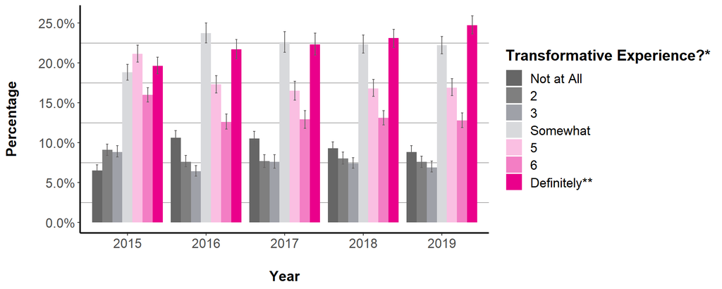

Error bars indicate the upper and lower bounds of the 95% confidence intervals.

* The exact wording of this question in the online survey was, "Did you have a transformative experience in Black Rock City this year?"  
** In the 2015 online survey this answer options was "Absolutely." In all following years, the option was changed to "Definitely."

|  | 2015 Percent | 2015 MoE +/- % |  | 2016 Percent | 2016 MoE +/- % |  | 2017 Percent | 2017 MoE +/- % |  | 2018 Percent | 2018 MoE +/- % |  | 2019 Percent | 2019 MoE +/- % |
| --- | --- | --- | --- | --- | --- | --- | --- | --- | --- | --- | --- | --- | --- | --- |
| Not at All | 6.5 | 0.6 |  | 10.6 | 0.8 |  | 10.5 | 1.0 |  | 9.3 | 0.8 |  | 8.8 | 0.8 |
| 2 | 9.1 | 0.8 |  | 7.6 | 0.8 |  | 7.7 | 0.8 |  | 8.0 | 0.8 |  | 7.6 | 0.8 |
| 3 | 8.8 | 0.8 |  | 6.4 | 0.6 |  | 7.6 | 0.8 |  | 7.4 | 0.6 |  | 6.9 | 0.8 |
| Somewhat | 18.8 | 1.0 |  | 23.7 | 1.2 |  | 22.6 | 1.4 |  | 22.3 | 1.2 |  | 22.2 | 1.2 |
| 5 | 21.1 | 1.0 |  | 17.3 | 1.2 |  | 16.5 | 1.2 |  | 16.8 | 1.0 |  | 16.9 | 1.0 |
| 6 | 16.0 | 1.0 |  | 12.6 | 1.0 |  | 12.9 | 1.2 |  | 13.1 | 1.0 |  | 12.8 | 1.0 |
| Definitely** | 19.6 | 1.0 |  | 21.7 | 1.2 |  | 22.3 | 1.4 |  | 23.1 | 1.2 |  | 24.7 | 1.2 |

## Transformative Experience

# Degree of Expectation of a Transformative Experience* in Black Rock City

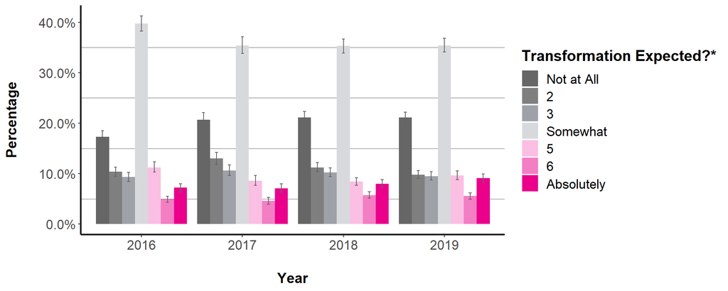

Error bars indicate the upper and lower bounds of the 95% confidence intervals.

* Data presented in the plot above and table below are for participants who reported experiencing a transformative experience in Black Rock City during each event year. The exact wording of this question in the online survey was, "Did you go to Burning Man expecting this transformation?"

|  | 2016 Percent | 2016 MoE +/- % |  | 2017 Percent | 2017 MoE +/- % |  | 2018 Percent | 2018 MoE +/- % |  | 2019 Percent | 2019 MoE +/- % |
| --- | --- | --- | --- | --- | --- | --- | --- | --- | --- | --- | --- |
| Not at All | 17.3 | 1.2 |  | 20.7 | 1.4 |  | 21.1 | 1.2 |  | 21.1 | 1.2 |
| 2 | 10.4 | 1.0 |  | 13.0 | 1.2 |  | 11.2 | 1.0 |  | 9.8 | 0.8 |
| 3 | 9.3 | 1.0 |  | 10.6 | 1.0 |  | 10.2 | 0.8 |  | 9.5 | 0.8 |
| Somewhat | 39.8 | 1.6 |  | 35.4 | 1.6 |  | 35.3 | 1.4 |  | 35.4 | 1.4 |
| 5 | 11.2 | 1.0 |  | 8.6 | 1.0 |  | 8.4 | 0.8 |  | 9.6 | 0.8 |
| 6 | 4.9 | 0.6 |  | 4.6 | 0.8 |  | 5.7 | 0.6 |  | 5.6 | 0.6 |
| Absolutely | 7.2 | 0.8 |  | 7.1 | 0.8 |  | 8.0 | 0.8 |  | 9.1 | 0.8 |

## Transformative Experience

# Degree of Desirability of a Transformative Experience* in Black Rock City

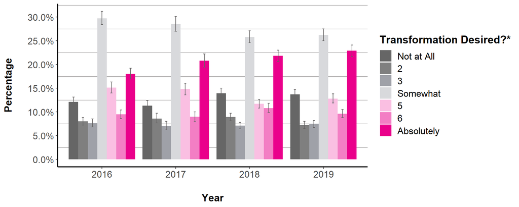

Error bars indicate the upper and lower bounds of the 95% confidence intervals.

* Data presented in the plot above and table below are for participants who reported experiencing a transformative experience in Black Rock City during each event year. The exact wording of this question in the online survey was, "Did you go to Burning Man desiring this transformation?"

|  | 2016 Percent | 2016 MoE +/- % |  | 2017 Percent | 2017 MoE +/- % |  | 2018 Percent | 2018 MoE +/- % |  | 2019 Percent | 2019 MoE +/- % |
| --- | --- | --- | --- | --- | --- | --- | --- | --- | --- | --- | --- |
| Not at All | 12.1 | 1.0 |  | 11.3 | 1.0 |  | 13.9 | 1.0 |  | 13.7 | 1.0 |
| 2 | 8.0 | 0.8 |  | 8.6 | 1.0 |  | 8.9 | 0.8 |  | 7.2 | 0.8 |
| 3 | 7.6 | 0.8 |  | 7.0 | 0.8 |  | 7.1 | 0.8 |  | 7.5 | 0.8 |
| Somewhat | 29.7 | 1.4 |  | 28.5 | 1.6 |  | 25.8 | 1.2 |  | 26.2 | 1.2 |
| 5 | 15.1 | 1.2 |  | 14.8 | 1.2 |  | 11.7 | 1.0 |  | 12.8 | 1.0 |
| 6 | 9.5 | 0.8 |  | 9.0 | 1.0 |  | 10.8 | 1.0 |  | 9.6 | 0.8 |
| Absolutely | 18.0 | 1.2 |  | 20.8 | 1.4 |  | 21.8 | 1.2 |  | 22.9 | 1.2 |

## Transformative Experience

# Persistence of Transformative Experience* After Departing Black Rock City

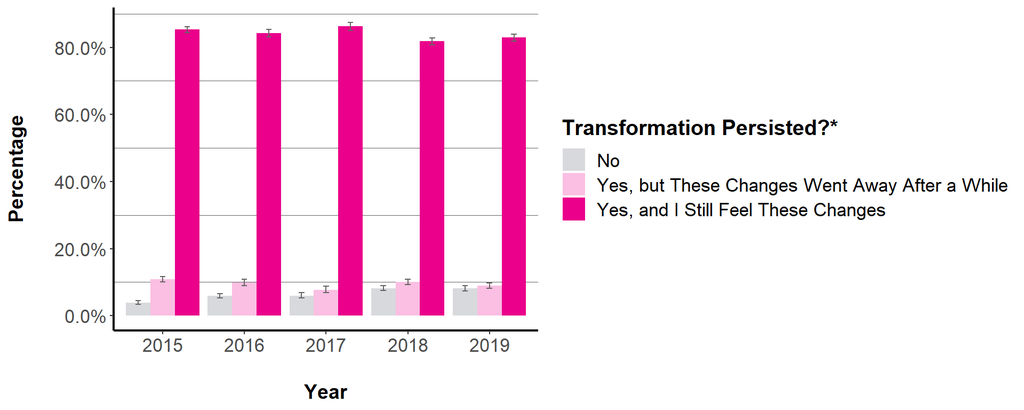

Error bars indicate the upper and lower bounds of the 95% confidence intervals.

* Data presented in the plot above and table below are for participants who reported experiencing a transformative experience in Black Rock City during each event year. The exact wording of this question in the online survey was, "Did this transformation persist after you left Black Rock City?"

|  | 2015 Percent | 2015 MoE +/- % |  | 2016 Percent | 2016 MoE +/- % |  | 2017 Percent | 2017 MoE +/- % |  | 2018 Percent | 2018 MoE +/- % |  | 2019 Percent | 2019 MoE +/- % |
| --- | --- | --- | --- | --- | --- | --- | --- | --- | --- | --- | --- | --- | --- | --- |
| No | 3.9 | 0.6 |  | 5.9 | 0.8 |  | 5.9 | 0.8 |  | 8.2 | 0.8 |  | 8.2 | 0.8 |
| Yes, but These Changes Went Away After a While | 10.8 | 0.8 |  | 9.9 | 1.0 |  | 7.7 | 1.0 |  | 10.0 | 0.8 |  | 8.9 | 0.8 |
| Yes, and I Still Feel These Changes | 85.3 | 1.0 |  | 84.2 | 1.2 |  | 86.3 | 1.2 |  | 81.8 | 1.2 |  | 82.9 | 1.2 |

## Transformative Experience

### Duration of Transformative Experience After Departing Black Rock City*

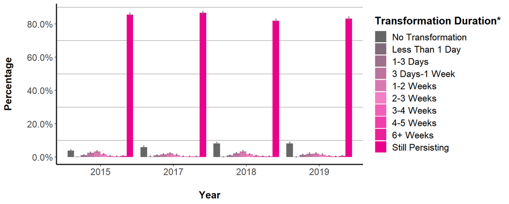

Error bars indicate the upper and lower bounds of the 95% confidence intervals.

* Options were changed in 2016 and were not directly comparable.

|  | 2015 Percent | 2015 MoE +/- % |  | 2017 Percent | 2017 MoE +/- % |  | 2018 Percent | 2018 MoE +/- % |  | 2019 Percent | 2019 MoE +/- % |
| --- | --- | --- | --- | --- | --- | --- | --- | --- | --- | --- | --- |
| No Transformation | 3.9 | 0.6 |  | 6.0 | 0.8 |  | 8.2 | 0.8 |  | 8.2 | 0.8 |
| Less Than 1 Day | 0.1 | 0.0 |  | 0.2 | 0.2 |  | 0.1 | 0.0 |  | 0.1 | 0.0 |
| 1-3 Days | 1.1 | 0.2 |  | 1.0 | 0.4 |  | 0.9 | 0.2 |  | 1.3 | 0.4 |
| 3 Days-1 Week | 2.6 | 0.4 |  | 1.6 | 0.4 |  | 2.2 | 0.4 |  | 2.0 | 0.4 |
| 1-2 Weeks | 3.4 | 0.4 |  | 2.2 | 0.6 |  | 3.4 | 0.6 |  | 2.1 | 0.4 |
| 2-3 Weeks | 1.7 | 0.4 |  | 1.3 | 0.4 |  | 1.7 | 0.4 |  | 1.5 | 0.4 |
| 3-4 Weeks | 0.7 | 0.2 |  | 0.4 | 0.2 |  | 0.8 | 0.2 |  | 0.7 | 0.2 |
| 4-5 Weeks | 0.4 | 0.2 |  | 0.4 | 0.2 |  | 0.5 | 0.2 |  | 0.3 | 0.2 |
| 6+ Weeks | 0.6 | 0.2 |  | 0.4 | 0.2 |  | 0.4 | 0.2 |  | 0.6 | 0.2 |
| Still Persisting | 85.6 | 1.0 |  | 86.6 | 1.2 |  | 81.9 | 1.2 |  | 83.1 | 1.0 |

## Transformative Experience

# Self-Report of Whether a Transformative Experience was Aided by Music

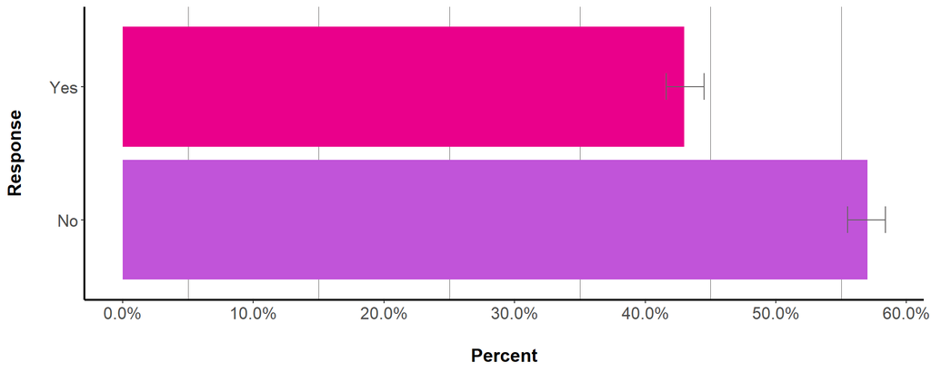

Error bars indicate the upper and lower bounds of the 95% confidence intervals.

*This question was first asked in 2019.

|  | 2019 Percent | 2019 MoE +/- % |
| --- | --- | --- |
| Yes | 43.0 | 1.4 |
| No | 57.0 | 1.4 |

**Next:** Perspectives on Burning Man: The 10 Principles